# Northern Three Spatial Analyses (Habitat: Mangroves and Saltmarshes)

Author

Adam Shand

Published

May 28, 2024

**R Version**

For R session info at the time of rendering this script see Section 6.

# 1 Introduction

This script contains the methods used to wrangle, analyse and present mangrove and saltmarsh data in the Northern Three regions. This data is a subset of the regional ecosystem data, for a guide on downloading regional ecosystem data refer to the README document for the Spatial Analysis GitHub repo.

Mangrove and saltmarsh (M&S) data is currently used within the estuarine habitat and hydrology section of the technical report. The amount of M&S lost/gained is the metric assessed. Therefore the main objectives of this script are to:

- Define the estuarine area of each basin in each region of the Northern Three team
- Select only M&S data in these areas
- Calculate the total amount of M&S coverage for each dataset from “pre-clear” to present.
- Create a tabular summary of the coverage
- Create maps of the coverage

# 2 Script Set Up

This script requires multiple core spatial packages, all packages are loaded below.

```r
library(sf)
library(tmap)
library(grid)
library(glue)
library(here)
library(tidyverse)
```

We also need to set up key variables for the script such as where we are going to save the outputs, and what coordinate reference system (crs) we are going to be using. Note that the crs is first established under ‘params’ at the start of the script.

A side note here, because data is not updated every year, even when we create a new folder under a new financial year does not necessarily mean that there will be new results. E.g. the years of mangrove and saltmarsh data (a subsection of the regional ecosystem data) we have are currently pre_clear, 1997, 1999, 2000, 2001, 2003, 2005, 2006, 2006b, 2007, 2009, 2011, 2013, 2015, 2017, 2019, and 2021. So if we were to put financial year 2001 or financial year 2002 we would still get the same results.

To make matters worse, the year of data (e.g. 2021) is not released on that same year, but at a later date. Specifically, the 2021 data was released in late 2023.

Thus instead of trying to name folders with just the financial years we will name folders with financial years and data layer years using a translation as follows:

fyear = 2023, data layer = 2021 fyear = 2022/21 data layer = 2019 fyear = 2020/19, data layer = 2017 fyear = 2018/17, data layer = 2015 fyear = 2016/15, data layer = 2013

```r
#get the targeted financial year that was set in the yaml
current_fyear <- params$target_fyear

#get the data year that we should look at using this relationship
data_year <- ifelse(current_fyear %in% c(2023), 2021,
                    ifelse(current_fyear %in% c(2022, 2021), 2019,
                           ifelse(current_fyear %in% c(2020, 2019), 2017,
                                  ifelse(current_fyear %in% c(2018, 2017), 2015,
                                         ifelse(current_fyear %in% c(2016, 2015), 2013)))))

#we also need to figure out what the most recent previous dataset is - this is useful later on (we dont need to bother going super far back)
prev_data_year <- ifelse(data_year == 2021, 2019,
                         ifelse(data_year == 2019, 2017,
                                ifelse(data_year == 2017, 2015,
                                       ifelse(data_year == 2015, 2013))))
```

# 3 Load Data

Now the script is set up we need to load in all of the required datasets. This will be broken into two segments: - Spatial data specific to the N3 region - such as the region, basin, and sub basin boundaries. - Regional Ecosystem data.

## 3.1 Spatial Data

Spatial data for the northern three regions should be readily available in the repo, the dataset is created by the n3_region-builder.qmd script in the repo that should be the first script run for new users. If the dataset is not available refer back to the README document in the GitHub repo. The other parts of spatial data here should go off without a hitch if the region-builder script has been run.

```r
#read in the northern three spatial files and reduce down to only the components we need
n3_region <- st_read(here("data/n3_region-builder/n3_region.gpkg")) |>
  filter(environment != "Marine") |>
  group_by(region, environment, basin_or_zone, sub_basin_or_sub_zone) |> summarise(geom = st_union(geom)) |>
  rename(basin = basin_or_zone, sub_basin = sub_basin_or_sub_zone) |> ungroup() |>
  st_cast() |> st_make_valid()

#load a Queensland outline from the aims package
qld <- get(data("gbr_feat", package = "gisaimsr")) |> filter(FEAT_NAME %in% c("Mainland", "Island")) |>
  st_transform(proj_crs)
```

## 3.2 Regional Ecosystem Data

**Note**

This section of the code takes a significant chunk of time to run. Processes have been put in place to reduce the need to rerun this step, however the inclusion of any new regional ecosystem layers as they are published will need to be run through this step.

**Note**

Only the newest and oldest RE layers are provided by QSpatial. If middle layers are missing, refer to README regarding download all layers. Note that the middle layers are not necessarily required for the script to run, but certain outputs benefit from the inclusion of additional layers.

Regional Ecosystem (RE) data (i.e. vegetation) is published to QSpatial by DES and covers the entirety of Queensland (for more info go [here](https://www.qld.gov.au/environment/plants-animals/plants/ecosystems/descriptions)). Vegetation type is given via an RE code such as “11.1.3” where:

- 11 = bioregion (e.g. The Brigalow Belt).
- 1 = landzone (e.g. Tidal flats and beaches).
- 3 = vegetation community (e.g. Sedgelands on marine clay plains).

Regional Ecosystem data is used by multiple scripts under the “habitat” banner in this repo. Because data is frequently used the raw data is stored in a generic data folder that is accessible by all habitat scripts. This is an exception to general repo data storage rules and is noted as such in the README.

### 3.2.1 Getting the Data

The following code chunk executes several key steps all at once, this is because running each of these steps takes a significant chunk of time and we can create an if-else statement that skips every single step if it has already been done. Each of these steps is quite detailed so we will spend some time explaining each process. I have tried to highlight each step that is known to take a long time, here we will:

The short names that we will use to “translate” the RE codes are:

[output not shown]

Please note that while short names might be the same across regions, the exact vegetation it refers to could be slightly different. When analyzing vegetation types closely also check the long name for more detail. We will also add three more short names for the remain vegetation groups that don’t fit into the mangroves and saltmarshes category. These groups are:

- “Water” - self explanatory but this will actually grab the “water”, “estuary”, “ocean”, and “shallow” RE groups.
- “Other Vegetation” - which is any other remnant vegetation in the area
- “Non-Remnant Vegetation” - which, broadly speaking, is vegetation that has been at least 50% cleared by anthropogenic factors.

```r
#create paths to where all the files will be saved
path1 <- here("data/n3_habitat_mangroves-and-saltmarshes/mangroves_and_saltmarshes.gpkg")
path2 <- here("data/n3_habitat_mangroves-and-saltmarshes/mangroves_and_saltmarshes.csv")

if (all(file.exists(c(path1, path2)))){#if both datasets exists, read them in

  re_map_data <- st_read(path1)
  re_tbl_data <- read.csv(path2)

  #reestablish units as they are wiped by the .csv format
  re_tbl_data$area <- units::set_units(re_tbl_data$area, km^2)

} else {#begin the process of creating the files (note that even if only one is missing, we need to recreate both)

  #create a polygon for the estuarine areas with a small buffer zone
  est_poly <- n3_region |> filter(environment == "Estuarine") |> st_buffer(0.001)

  #get path to the raw layers and the edited layers
  raw_path <- here("data/n3_habitat/re_raw/")
  cropped_path <- here("data/n3_habitat_mangroves-and-saltmarshes/re_mangroves_and_saltmarshes_cropped/")

  #get list of files in the read folder that contain "re_" and .gpkg" without their extension
  file_list <- tools::file_path_sans_ext(list.files(raw_path, pattern = ".gpkg"))

  #create a vector to track objects created
  years_loaded <- c()

  for (i in file_list){#for each file in list (excluding cropped versions)

    if (file.exists(glue("{cropped_path}/{i}_cropped.gpkg"))){#if the cropped version exists
      writeLines("\n\nCropped file exists, data loaded from storage.\n")

      #read it in
      re_layer <- st_read(glue("{cropped_path}/{i}_cropped.gpkg"))

      #edit the name
      i <- str_remove_all(i, "^re_|_v12_2")

      #keep track of the new object names
      years_loaded <- append(years_loaded, i)

      #assign it to the global environment
      assign(i, re_layer)

    } else {
      writeLines("\nCropped file does not exists, data will be cropped, saved, then loaded.\n")

      #create look up to optionally rename the geometry column
      lookup <- c(geom = "Shape", Shape_Length = "Shape_Leng")

      #read in the original regional ecosystem layer
      re_layer <- st_read(glue("{raw_path}/{i}.gpkg")) |> rename(any_of(lookup))

      #and separate the data into "standard" geometries - polygons, and non-standard geometries - e.g. multisurfaces
      standard_geoms <- re_layer |> filter(grepl("POLYGON", st_geometry_type(geom))) |> st_make_valid()
      non_standard_geoms <- re_layer |> filter(grepl("MULTISURFACE", st_geometry_type(geom)))

      #save non-standard geoms to be edited
      st_write(non_standard_geoms, glue("{cropped_path}/temporary_storage.gpkg"), delete_dsn = T)

      #use the gdalUtilies to open edit and save the file (it auto saves as a folder containing a shapefile)
      gdalUtilities::ogr2ogr(glue("{cropped_path}/temporary_storage.gpkg"), glue("{cropped_path}/temporary_storage"),
                             explodecollections = T, nlt = 'CONVERT_TO_LINEAR', overwrite = T)

      #read back in the edited file
      fixed_geoms <- st_read(glue("{cropped_path}/temporary_storage/temporary_storage.shp")) |>
        rename(any_of(lookup)) |> st_make_valid()

      #join the fixed data onto the standard data
      re_layer <- rbind(standard_geoms, fixed_geoms)

      #transform the crs, then intersect over the bvg area
      re_layer <- re_layer |> st_transform(proj_crs) |> st_intersection(est_poly)

      #save the file
      st_write(re_layer, glue("{cropped_path}/{i}_cropped.gpkg"), append = F)

      #edit the name
      i <- str_remove_all(i, "^re_|_v12_2")

      #keep track of the new object names
      years_loaded <- append(years_loaded, i)

      #assign it to the global environment
      assign(i, re_layer)

    }
  }

  for (i in years_loaded){#create a year column then assign it to the correct name again
    writeLines("\nAssigning layer years.")

    #get the specific layer and add the year
    data <- get(i) |> mutate(year = i) |> select(-any_of(c("OBJECTID", "Shape_Length", "Shape_Area")))

    #reassign data to the correct name
    assign(i, data)

  }

  #create a list containing all of the datasets that were loaded in
  data_set_list <- lapply(years_loaded, function(x) get(x))

  #bind all datasets together
  writeLines("\nBinding data.\n")
  re_est <- do.call(rbind, data_set_list)

  #create look up to optionally rename the geometry column
  lookup <- c(geom = "Shape")

  #rename if needed, then calculate area
  re_est <- re_est |> rename(any_of(lookup)) |> mutate(area_m = st_area(geom))

  #update units to be km2
  re_est$area <- units::set_units(re_est$area_m, km^2)

  #split the main RE column into multiple columns
  re_est <- re_est |> select(RE, PERCENT, region, basin, sub_basin, year, area) |>
    separate(RE, into = c("RE_1", "RE_2", "RE_3", "RE_4", "RE_5"), sep = "/") |>
    separate(PERCENT, into = c("PC_1", "PC_2", "PC_3", "PC_4", "PC_5"), sep = "/")

  ##################
  #Doing the map version
  ##################

  #take only the dominant RE (RE_1), then get only polygons
  re_map_data <- re_est |> select(RE_1, region, basin, sub_basin, year) |>
    st_collection_extract(type = "POLYGON", warn = F)

  #assign custom vegetation names to the data
  re_map_data <- re_map_data |>
    mutate(vegetation = case_when(str_detect(RE_1, "7.1.1|7.1.4|8.1.1|11.1.4") ~ "Mangroves",
                                  str_detect(RE_1, "7.1.2|7.1.3|7.1.5|8.1.2|8.1.3|8.1.4|8.1.5|11.1.1|11.1.2|11.1.3") ~ "Saltmarshes",
                                  str_detect(RE_1, "estuary|shallow|ocean|water") ~ "Water",
                                  str_detect(RE_1, "non-remnant") ~ "Non-Remnant Vegetation",
                                  T ~ "Other Vegetation"))

  #union features by the custom names to improve map visibility
  re_map_data <- re_map_data |> group_by(region, basin, sub_basin, year, vegetation) |>
    summarise(geom = st_union(geom)) |> ungroup()

  #save the map version of the data
  st_write(re_map_data, path1, append = F)

  ##################
  #Now doing the table version
  ##################

  #drop geometry and calculate associated percentages
  re_tbl_data <- re_est |> st_drop_geometry() |>
    mutate(across(matches("PC"), as.numeric),
           area_1 = (PC_1*area)/100,
           area_2 = (PC_2*area)/100,
           area_3 = (PC_3*area)/100,
           area_4 = (PC_4*area)/100,
           area_5 = (PC_5*area)/100)

  #pivot table longer - note that this requires very specific names to work: value_set
  re_tbl_data <- re_tbl_data |> select(!area) |>
    pivot_longer(-c(region, basin, sub_basin, year), #look at every column except region, basin, sub_basin, and year
                 names_to = c(".value", "set"), #create a column called "set" and n number of columns for the unique values we find
                 names_pattern = "(.+)_(.+)") #for columns selected, separate col name either side of the underscore.
#The right side of the underscore = the values to put in the "set" column (1, 2, 3, 4, 5).
#The left side of the underscore = the values to put in our .values column(s), values are put into columns based on each unique sequence of characters returned (e.g. all column names starting with RE get grouped, all column names starting with PC get grouped, all columns starting with area get grouped)

  #drop rows containing NA, and the set column
  re_tbl_data <- re_tbl_data |> drop_na() |> select(!set)

  #assign custom vegetation names to the data
  re_tbl_data <- re_tbl_data |>
    mutate(vegetation = case_when(str_detect(RE, "7.1.1|7.1.4|8.1.1|11.1.4") ~ "Mangroves",
                                  str_detect(RE, "7.1.2|7.1.3|7.1.5|8.1.2|8.1.3|8.1.4|8.1.5|11.1.1|11.1.2|11.1.3") ~ "Saltmarshes",
                                  str_detect(RE, "estuary|shallow|ocean|water") ~ "Water",
                                  str_detect(RE, "non-remnant") ~ "Non-Remnant Vegetation",
                                  T ~ "Other Vegetation"))

  #save the data
  write.csv(re_tbl_data, path2, row.names = F)

  #clean up and force a garbage collection
  rm(list = years_loaded)
  unlink(glue("{cropped_path}/temporary_storage.gpkg"))
  unlink(glue("{cropped_path}/temporary_storage"), recursive = T)
  rm(est_poly, re_est, lookup, cropped_path, data, data_set_list, file_list, fixed_geoms,
     non_standard_geoms, raw_path, standard_geoms, years_loaded)
  gc()

}

#clean up paths
rm(path1, path2)
```

# 4 Analyse Data

Once we have boiled down the vegetation to the specific groups we want we can begin the analysis. Currently we are looking to calculate:

- The total area coverage by each vegetation in each basin for each year.
- The total area coverage of the mangrove and saltmarsh combined category
- The proportion of the total area that each vegetation covers.
- The change year on year of each vegetation.
- The standardised score for each vegetation type

## 4.1 Calculate Total Vegetation Coverage and Proportional Coverage

Here we can group by region basin and year to get total cover, then use rowwise to divide by each vegetation type, and then group by the custom re to get a final sum and percent for each re in each basin in each year.

```r
#calculate the total area of each basin for each year and the proportion each vegetation covers
re_tbl_data <- re_tbl_data |>
  group_by(region, basin, sub_basin, year) |> mutate(total_surveyed_area = sum(area)) |>
  ungroup() |>
  rowwise() |> mutate(veg_percent_of_total_area = as.numeric((area/total_surveyed_area)*100)) |>
  ungroup() |>
  group_by(region, basin, sub_basin, year, total_surveyed_area, vegetation) |>
  summarise(area = sum(area),
            veg_percent_of_total_area = sum(veg_percent_of_total_area)) |>
  ungroup()

#are all basins represented in sub basins?
if(!all(unique(unique(re_tbl_data$basin) %in% unique(re_tbl_data$sub_basin)))){#if not:

  #create basin version
  basin_temp_tbl <- re_tbl_data |> filter(basin != sub_basin) |>
    group_by(region, basin, year, vegetation) |>
    summarise(total_surveyed_area = sum(total_surveyed_area),
              area = sum(area),
              veg_percent_of_total_area = as.numeric((area/total_surveyed_area)*100)) |>
    ungroup() |>
    mutate(sub_basin = basin)

  #bind together
  re_tbl_data <- rbind(re_tbl_data, basin_temp_tbl)

}

#clean up
rm(basin_temp_tbl)
```

## 4.2 Create a Mangrove + Saltmarsh combined category

When reporting the mangrove and saltmarsh data we currently have to report them in a combined format, as if they were one single vegetation type. Below we combine the groups into one.

```r
#create a mangrove and saltmarsh only version
m_and_s <- re_tbl_data |>
  filter(vegetation %in% c("Mangroves", "Saltmarshes")) |>
  group_by(region, basin, sub_basin, year) |>
  summarise(vegetation = "Mangroves and Saltmarshes Combined",
            area = sum(area),
            total_surveyed_area = mean(total_surveyed_area),
            veg_percent_of_total_area = sum(veg_percent_of_total_area)) |>
  ungroup()

#add back to main
re_tbl_data <- rbind(re_tbl_data, m_and_s)

#cleanup
rm(m_and_s)
```

## 4.3 Calculate Year on Year Change

After calculating the area each vegetation types covers (and had previously covered) we can then do a year on year comparison to track the loss/gain over time. A good trick here is to order by vegetation type, so we can then use the lag() function to query the above row.

```r
#create a set of rows for non remnant vegetation in the pre clear year (this is obviously 0 but helps with calculations below)
non_rem_tbl <- re_tbl_data |> filter(year == "pre_clear", vegetation == "Mangroves") |>
  mutate(area = 0, veg_percent_of_total_area = 0, vegetation = "Non-Remnant Vegetation")

#add units to temp table
non_rem_tbl$area <- units::set_units(non_rem_tbl$area, km^2)

#bind these new rows to the main data
re_tbl_data <- bind_rows(re_tbl_data, non_rem_tbl)

#create a 0 value with units
replace_value <- units::set_units(0, km^2)

#order by vegetation, group by basin and veg, then compare the row to the one above using lag(), replace na values with 0
re_tbl_data <- re_tbl_data |> arrange(sub_basin, vegetation, year) |>
  group_by(basin, sub_basin, vegetation) |>
  mutate(y_on_y_veg_area_change = area - lag(area),
         y_on_y_veg_percent_change = (y_on_y_veg_area_change/lag(area))*100) |>
  mutate(across(matches("percent"), \(x) as.vector(x)),
         across(matches("percent"), \(x) replace_na(x, 0)),
         across(matches("area"), \(x) replace_na(x, replace_value)),
         across(where(is.numeric), \(x) round(x, 5))) |>
  ungroup()

#fix up erraneous percent change values (anything over 100% change gets a score of 100)
re_tbl_data <- re_tbl_data |>
  mutate(y_on_y_veg_percent_change = case_when(abs(y_on_y_veg_percent_change) > 100 ~ 100,
                                               T ~ y_on_y_veg_percent_change))
```

## 4.4 Calculate Standardised Scores

We can then use the percent change year on year to calculate the standardised scores for each vegetation type

```r
standardised_m_and_s <- function (x){

  if (x > 0){floor(100-abs(19-((abs(x)-0)*(19/99.9))))}
  else if (x >= -0.1){floor(61+abs(19.9-((abs(x)-0)*(19.9/0.1))))}
  else if (x >= -0.5){floor(41+abs(19.9-((abs(x)-0.11)*(19.9/0.39))))}
  else if (x >= -3){floor(21+abs(19.9-((abs(x)-0.51)*(19.9/2.49))))}
  else if (x < -3){floor(abs(20.9-((abs(x)-3.01)*(20.9/96.99))))}
}


re_tbl_data <- re_tbl_data |>
  rowwise() |>
  mutate(standardised_score = standardised_m_and_s(y_on_y_veg_percent_change))
```

Once that is done we can save the full table to the outputs folder.

```r
#create a new version just to update values to ha instead of km2
save_version <- re_tbl_data |>
  mutate(area = round(area*100, 1),
         y_on_y_veg_area_change = round(y_on_y_veg_area_change*100, 1),
         y_on_y_veg_percent_change = round(y_on_y_veg_percent_change, 2))

#save full table
write.csv(save_version, glue("{save_path}/mangrove-and-saltmarsh_full_table.csv"), row.names = F)

#edit cells of year column then pivot data for a clean presentation
report_ready <- save_version |>
  mutate(year = str_remove(year, "remnant_"),
         year = case_when(is.na(year) ~ "pre_clear",
                          T ~ year)) |>
  select(!c(total_surveyed_area, veg_percent_of_total_area)) |>
  filter(str_detect(vegetation, c("Mang|Salt"))) |>
  rename(area_change = y_on_y_veg_area_change,
         percent_change = y_on_y_veg_percent_change) |>
  mutate(standardised_score = case_when(year == data_year ~ standardised_score,
                                        T ~ NA)) |>
  pivot_wider(names_from = year, values_from = c(area, area_change, percent_change))

#compress the table
report_ready <- report_ready |>
  group_by(sub_basin, vegetation) |>
  mutate(across(5:ncol(report_ready)-2, ~sum(.x, na.rm = T))) |>
  ungroup() |>
  unique()

#create custom variables for column selection
cols_to_select <- c(glue("area_{prev_data_year}"), glue("area_{data_year}"), glue("change_{data_year}"))

#select oldest and two most recent years of data for area, and only most recent for change
report_ready <- report_ready |>
  select(region, basin, sub_basin, vegetation, area_pre_clear, matches(cols_to_select), standardised_score) |>
  mutate(vegetation = factor(vegetation),
         vegetation = fct_relevel(vegetation, "Mangroves", "Saltmarshes", "Mangroves and Saltmarshes Combined")) |>
  arrange(vegetation)

#pviot data again, combining the vegetation type with the values
report_ready <- report_ready |>
  pivot_wider(names_from = vegetation,
              values_from = c(5:ncol(report_ready)),
              names_glue = "{vegetation}_{.value}", names_sort = T) #names_glue provides a pattern for the naming to happen

#create a vector of the three names types we have
m <- names(report_ready)[str_detect(names(report_ready), "groves_")]
s <- names(report_ready)[str_detect(names(report_ready), "marshes_")]
m_s <- names(report_ready)[str_detect(names(report_ready), " and ")]

#plus one of columns we wish to remove
remo <- names(report_ready[str_detect(names(report_ready), "standardised")
                           & !str_detect(names(report_ready), " and ")])

#"relocate" the first three sets, first putting mangroves at the end, then saltmarsh, then combined. Creates the right order. Then remove the forth set
report_ready <- report_ready |>
  relocate(any_of(c(m,s,m_s)), .after = last_col()) |>
  select(!any_of(remo))

#load in our custom colouring function
source(here("functions/cond_form_rc_grades.R"))

#run function, noting to specify which colour system we want to use
cond_form_rc_grades(report_ready, glue("{save_path}/mangrove_and_saltmarsh_report_table"),
                    cols = ncol(report_ready), method = "Numeric")

#clean up
rm(save_version)
```

# 5 Visualise Data

Now on to the fun stuff - visualizations. Below we are looking to present the data in a few different ways, by:

- Creating a horizontal stacked bar chart of the proportional of each group in each basin.
- Creating maps of mangrove and saltmarsh vegetation in each basin each year.
- Creating a plot over time of how total mangrove and saltmarsh vegetation has changed over time.
  - As an alternative we could create a bar chart with x as the time axis??

## 5.1 Streamline data

Before we can visualise we need to streamline our tbl data to remove some of the excessive rows that were created to calculate final scores.

```r
#drop rows that we don't need
re_tbl_data <- re_tbl_data |>
  filter(!(region == "Dry Tropics" & basin == sub_basin),
         !str_detect(vegetation, "and"))
```

## 5.2 Horizontal Stacked Bar Chart

The horizontal stacked bar chart will make use of the table version of the data as there is no spatial information required. First we will create a custom palette that ggplot will use as a reference for how to color groups.

```r
#create custom palette
my_tbl_palette <- c("#B8E08C", "#571111", "#D5B58B", "#2A7E54", "#75DBFF")

#assign names to my palette so ggplot can colour everything correctly
names(my_tbl_palette) <- sort(unique(re_tbl_data$vegetation))
```

Then we will create the plots, looping for each basin and each year. Note that the way the palette works is by matching the names of the palette variable we created to the cell values in the vegetation column.

```r
#list out basins
basins <- unique(n3_region$basin)

for (i in basins){#for each basin

  #select a specific basin and arrange the data appropriately
  basin_plot <- re_tbl_data |> filter(basin == i, year == glue("remnant_{data_year}")) |>
    arrange(desc(veg_percent_of_total_area)) |>
    mutate(vegetation = factor(vegetation, levels = unique(vegetation)))

  if (nrow(basin_plot) != 0){

    #create a plot
    plot <- ggplot(basin_plot, aes(fill = vegetation, x = basin, y = veg_percent_of_total_area)) +
      geom_bar(position = position_fill(reverse = T), stat = "identity") +
      scale_fill_manual(values = my_tbl_palette) +
      scale_x_discrete(expand = c(0.025, 0)) +
      scale_y_continuous(expand = c(0, 0), labels = scales::percent_format(accuracy = 1)) +
      labs(x = "", y = "", fill = glue("{i} \nMangroves and Saltmarshes")) +
      theme(axis.text.x = element_text(colour = "black"),
            axis.text.y = element_blank(),
            axis.line.x = element_line(colour = "black"),
            axis.ticks.length = unit(-0.15, "cm"),
            panel.background = element_blank()) +
      coord_flip()

    #edit names
    edit_i <- str_remove_all(str_to_lower(paste(i, data_year, sep = "_")), "_tbl")

    #save
    ggsave(glue("{save_path}/plots/{edit_i}_mangrove-and-saltmarsh_plot.png"), plot, width = 12, height = 4)

  }
}
```

Here is an example of how one of the plots looks, noting that the actual outputted version looks much nicer.

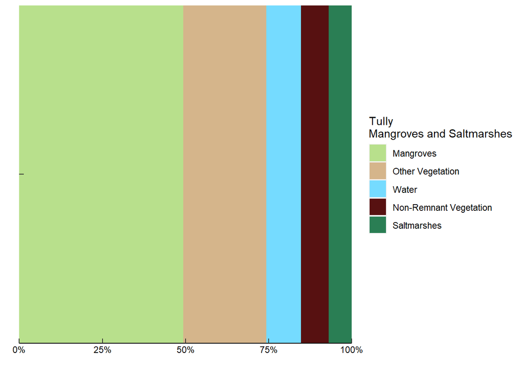

```r
plot
```

## 5.3 Map Mangroves and Saltmarshes

```r
#create custom palette
my_map_palette <- c("#B8E08C", "#571111", "#D5B58B", "#2A7E54", "#75DBFF")

#assign names to my palette so ggplot can colour everything correctly
names(my_map_palette) <- sort(unique(re_map_data$vegetation))
```

further, the method of implementation is slightly different as a different R package is used, matching the colours to the appropriate columns.

```r
#add an empty column to hold palette
re_map_data$palette <- NA

for (i in 1:length(my_map_palette)){#for the length of the palette, match each element

  #using the custom palette we created earlier
  re_map_data <- re_map_data |> mutate(palette = case_when(vegetation == names(my_map_palette)[i] ~ my_map_palette[[i]],
                                                           T ~ palette))
}
```

Then we will create the maps, same as above, looping over each basin.

```r
#drop environment out of the n3 region dataset (just creates unnecessary clutter)
n3_region <- n3_region |>
  group_by(region, basin, sub_basin) |> summarise(geom = st_union(geom)) |>
  ungroup() |> st_cast() |> st_make_valid()

#note we are using the target_year variable created earlier
for (i in unique(n3_region$region)){#for each basin

  #select region
  target_region <- re_map_data |> filter(region == i, year == glue("remnant_{data_year}"))

  #get the region outline
  region_outline <- n3_region |> filter(region == i)

  #create a bbox of the vegetation data
  reg_veg_bbox <- st_as_sfc(st_bbox(target_region))

  #create an inset map
  inset_map <- tm_shape(qld) +
    tm_polygons(col = "grey80", border.col = "black") +
    tm_shape(region_outline, is.master = T) +
    tm_polygons(col = "grey90", border.col = "black") +
    tm_shape(reg_veg_bbox) +
    tm_borders(lwd = 2, col = "red")

  #create a map of the area
  map <- tm_shape(qld) +
    tm_polygons(col = "grey80", border.col = "black") +
    tm_shape(region_outline) +
    tm_polygons(col = "grey90", border.col = "black") +
    tm_shape(target_region, is.master = T) +
    tm_fill(col = "palette") +
    tm_add_legend(type = "fill", col = unique(target_region$palette), labels = unique(target_region$vegetation)) +
    tm_shape(region_outline) +
    tm_borders(col = "black") +
    tm_layout(legend.frame = T, legend.bg.color = "White", asp = 1.1,
              legend.text.size = 0.7, legend.position = c("left", "bottom")) +
    tm_scale_bar(width = 0.15, text.size = 0.7, position = c(0.28, 0))

  #figure out the aspect of the inset map and the view port
  xy <- st_bbox(region_outline)
  asp2 <- (xy$ymax - xy$ymin)/(xy$xmax - xy$xmin)
  w <- 0.2
  h <- asp2 * w
  vp <- viewport(x = 0.985, y = 0.97, width = w, height = h, just = c("right", "top"))

  #edit names
  i <- str_replace_all(str_to_lower(i), " ", "_")

  #save the map as a png
  tmap_save(map, filename = glue("{save_path}/maps/{i}_region_mangroves-and-saltmarshes_map.png"),
            insets_tm = inset_map, insets_vp = vp)

  for (j in unique(target_region$basin)){

    #select basin from vegetation data
    target_basin <- re_map_data |> filter(basin == j, year == glue("remnant_{data_year}"))

    #check if data is empty
    if (nrow(target_basin) != 0){

      #get the basin outline from the n3 region dataset
      basin_outline <- n3_region |> filter(basin == j)

      #create a bbox of the vegetation data
      veg_bbox <- st_as_sfc(st_bbox(target_basin))

      #create an inset map
      inset_map <- tm_shape(qld) +
        tm_polygons(col = "grey80", border.col = "black") +
        tm_shape(region_outline, is.master = T) +
        tm_polygons(col = "grey90", border.col = "black") +
        tm_shape(veg_bbox) +
        tm_borders(lwd = 2, col = "red")

      #create a map of the area
      map <- tm_shape(qld) +
        tm_polygons(col = "grey80", border.col = "black") +
        tm_shape(basin_outline) +
        tm_polygons(col = "grey90", border.col = "black") +
        tm_shape(target_basin, is.master = T) +
        tm_fill(col = "palette") +
        tm_add_legend(type = "fill", col = unique(target_basin$palette), labels = unique(target_basin$vegetation)) +
        tm_shape(basin_outline) +
        tm_borders(col = "black") +
        tm_layout(legend.frame = T, legend.bg.color = "White", asp = 1.1,
                  legend.text.size = 0.7, legend.position = c("left", "bottom")) +
        tm_scale_bar(width = 0.15, text.size = 0.7, position = c(0.26, 0))

      #figure out the aspect of the inset map and the view port
      xy <- st_bbox(region_outline)
      asp2 <- (xy$ymax - xy$ymin)/(xy$xmax - xy$xmin)
      w <- 0.2
      h <- asp2 * w
      vp <- viewport(x = 0.985, y = 0.97, width = w, height = h, just = c("right", "top"))

      #edit names
      j <- str_replace_all(str_to_lower(j), " ", "_")

      #save the map as a png
      tmap_save(map, filename = glue("{save_path}/maps/{j}_basin_mangroves-and-saltmarshes_map.png"),
                insets_tm = inset_map, insets_vp = vp)
    }
  }
}
```

Here is an example of how one of the maps looks, noting that the actual outputted version looks much nicer.

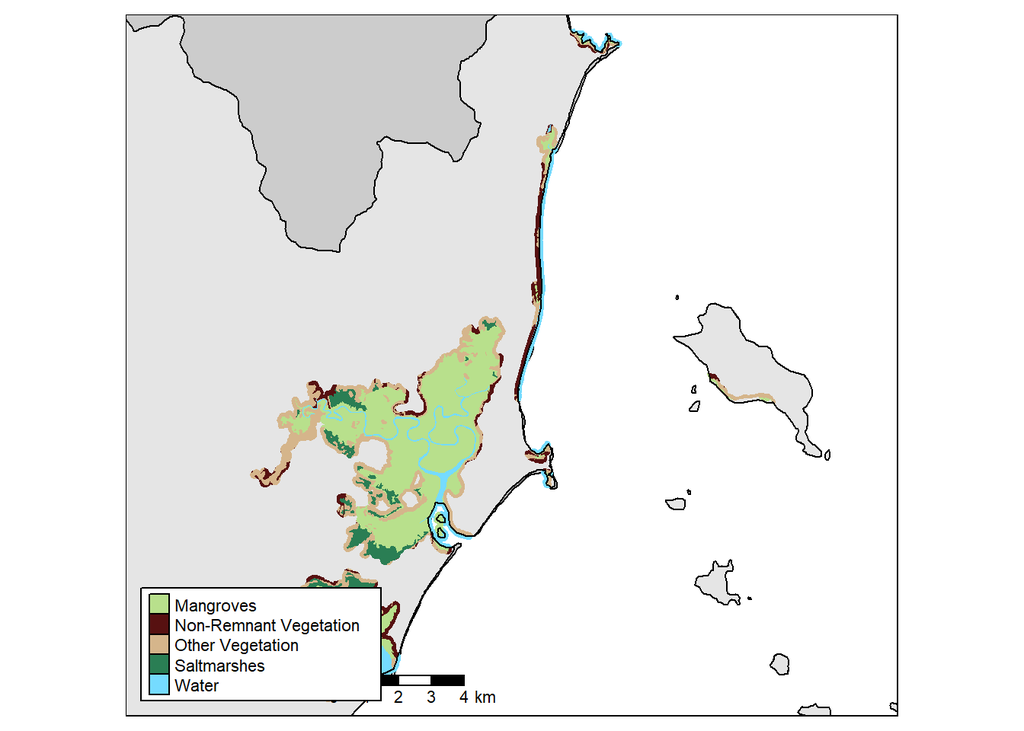

```r
map
```

## 5.4 Vegetation Over Time

Lastly we want to look at how the total amount of vegetation has changed over time. We will be using the percent change column in the table version to explore this.

Note, to make these plots more relevant we will not include the pre_clear or 1997 years because the change between these two is so huge it overshadows all other changes.

```r
#drop pre clear and 1997
re_tbl_data_filtered <- re_tbl_data |>
  filter(!year %in% c("pre_clear", "remnant_1997"))

#generate a list of potential years greater than the target data year
removal_years <- glue("remnant_{data_year+1:15}")

#remove data years that occured after the target data year
re_tbl_data_filtered <- re_tbl_data_filtered |>
  filter(!year %in% removal_years)

for (i in unique(n3_region$region)){

  #select the target area
  target_region_general <- re_tbl_data_filtered |> filter(region == i)

  #create region specific numbers
  target_region <- target_region_general |>
    select(region, year, vegetation, area) |>
    group_by(region, year, vegetation) |>
    summarise(area = sum(area)) |>
    ungroup() |>
    group_by(region, vegetation) |>
    arrange(vegetation, region, year) |>
    mutate(y_on_y_veg_area_change = area - lag(area),
           y_on_y_veg_percent_change = (y_on_y_veg_area_change/lag(area))*100,
           across(matches("percent"), \(x) as.vector(x)),
           across(matches("percent"), \(x) replace_na(x, 0)),
           across(matches("area"), \(x) replace_na(x, replace_value)),
           across(where(is.numeric), \(x) round(x, 5))) |>
    ungroup()

    #fix up erraneous percent change values (anything over 100% change gets a score of 100)
    target_region <- target_region |>
      mutate(y_on_y_veg_percent_change = case_when(abs(y_on_y_veg_percent_change) > 100 ~ 100,
                                                   T ~ y_on_y_veg_percent_change))

    #divide percent by 100 to correct for unit addition under 'scale_x_continuous()
    target_region_ordered <- target_region |>
      mutate(y_on_y_veg_percent_change = y_on_y_veg_percent_change/100) |>
      mutate(year = str_remove_all(year, "remnant_"))

    #reorder years
    target_region_ordered <- target_region_ordered |>
      mutate(year = factor(year, levels = unique(target_region_ordered$year)))

    #plot
    plot <- ggplot(target_region_ordered, aes(y_on_y_veg_percent_change, year, fill = vegetation)) +
      geom_bar(stat = "identity", position = "dodge") +
      scale_y_discrete(limits = rev) +
      scale_fill_manual(values = my_tbl_palette) +
      scale_x_continuous(labels = scales::percent_format(accuracy = 0.1)) +
      theme(axis.text.x = element_text(colour = "black"),
            axis.line.x = element_line(colour = "black"),
            axis.text.y = element_text(colour = "black"),
            axis.line.y = element_line(colour = "black"),
            axis.ticks.y = element_blank(),
            panel.background = element_blank()) +
      geom_vline(xintercept = 0) +
      geom_hline(yintercept = seq(1.5, length(unique(target_region_ordered$year))-0.5, 1),
                 lwd = 0.5, colour = "grey80") +
      labs(x = "Year on Year Change (%)", y = "Year", fill = glue("{j} {i}\nRiparian Vegetation"))

    #edit names
    i <- str_replace_all(str_to_lower(i), " ", "_")

    #save
    ggsave(glue("{save_path}/plots/{i}_region_mangrove_and_saltmarshes_change-over-time.png"), plot)

    for (j in unique(target_region_general$basin)){

      #select the target area
      target_basin <- target_region_general |> filter(basin == j)

      #divide percent by 100 to correct for unit addition under 'scale_x_continuous(), change year to factor for ordering
      target_basin_ordered <- target_basin |>
        group_by(basin, year, vegetation) |>
        summarise(y_on_y_veg_percent_change = sum(y_on_y_veg_percent_change)) |>
        mutate(y_on_y_veg_percent_change = y_on_y_veg_percent_change/100) |>
        mutate(year = str_remove_all(year, "remnant_"))

      #reorder years
      target_basin_ordered <- target_basin_ordered |>
        mutate(year = factor(year, levels = unique(target_basin_ordered$year)))

      #plot
      plot <- ggplot(target_basin_ordered, aes(y_on_y_veg_percent_change, year, fill = vegetation)) +
        geom_bar(stat = "identity", position = "dodge") +
        scale_y_discrete(limits = rev) +
        scale_fill_manual(values = my_tbl_palette) +
        scale_x_continuous(labels = scales::percent_format(accuracy = 0.1)) +
        theme(axis.text.x = element_text(colour = "black"),
              axis.line.x = element_line(colour = "black"),
              axis.text.y = element_text(colour = "black"),
              axis.line.y = element_line(colour = "black"),
              axis.ticks.y = element_blank(),
              panel.background = element_blank()) +
        geom_vline(xintercept = 0) +
        geom_hline(yintercept = seq(1.5, length(unique(target_basin_ordered$year))-0.5, 1),
                   lwd = 0.5, colour = "grey80") +
        labs(x = "Year on Year Change (%)", y = "Year", fill = glue("{j} {i}\nMangroves and Saltmarshes"))

      #edit names
      j <- str_replace_all(str_to_lower(j), " ", "_")

      #save
      ggsave(glue("{save_path}/plots/{j}_basin_mangrove_and_saltmarshes_change-over-time.png"), plot)

    }
}
```

Here is an example of how one of the change over time plots looks, noting that the actual outputted version looks much nicer.

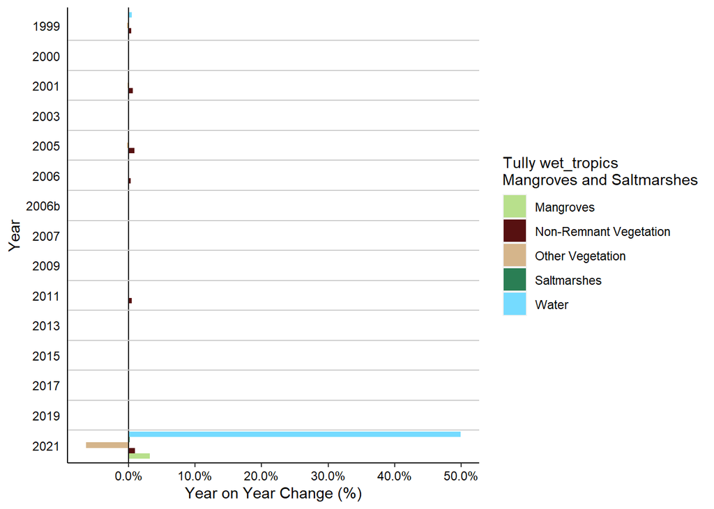

```r
plot
```

And that rounds out the script. Spicy.

# 6 Session Info

Below is the session info at the time of rendering this script. Of greatest importance is to note the R version, and the “other attached packages” as these are the most significant drivers of success/failure. It is also good to check the “attached base packages” and “loaded via a namespace” packages as well. To check your session info use `sessionInfo()`.

[session information not shown]

## Footnotes

[^1]: When mapping we can only show/use the dominant RE type for each row. This is because a row might have the original RE column of “11.1.1/11.1.3/11.1.5”, but the associated geometry for that group does not make any distinction/separation between groups. I.e. if we were to split up the column into “11.1.1”, “11.1.3”, “11.1.5”, pivot the data, and then try to plot each of them, they would each have an identical geometry and overlap one another.
[^2]: Mangrove and saltmarsh RE types are:
    - Wet Tropics: RE Groups = 7.1.1 - 7.1.5 inclusive.
    - Dry Tropics: RE Groups = 11.1.1 - 11.1.5 inclusive.
    - Mackay Whitsunday Issac: RE Groups = 8.1.1 - 8.1.5 inclusive.
[^3]: Mangrove and saltmarsh RE types are:
    - Wet Tropics: RE Groups = 7.1.1 - 7.1.5 inclusive.
    - Dry Tropics: RE Groups = 11.1.1 - 11.1.5 inclusive.
    - Mackay Whitsunday Issac: RE Groups = 8.1.1 - 8.1.5 inclusive.
[^4]: Because we are going to be calculating things such as “percent of total coverage” for each of our short names, we want to set the total coverage as the sum of all estuarine vegetation, not the sum of all things picked up in the estuarine boundary.